# Count Models Tutorial

Let’s just see what it looks like when we log-transform it. We will need to add ‘1’ to each value, because you can’t log-transform zeros.

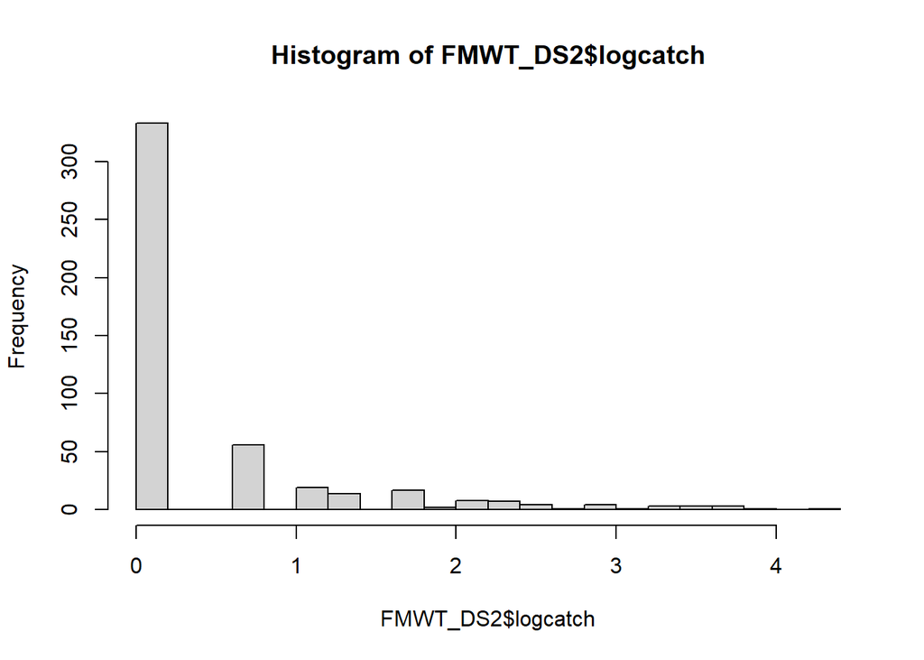

```r
FMWT_DS2$logcatch = log(FMWT_DS2$Catch +1)


hist(FMWT_DS2$logcatch, breaks = 30)
```

Well, unlike the striped bass data, we still don’t have a bell curve after log-transforming, which means that a Poisson distribution won’t work either. Just for the sake of the example, let’s see what happens when we run a linear model on this.

```r
dslm = lm(Catch~  Cond+Sec + Temp + Year, data = FMWT_DS2)
summary(dslm)
```

```
##
## Call:
## lm(formula = Catch ~ Cond + Sec + Temp + Year, data = FMWT_DS2)
##
## Residuals:
##    Min     1Q Median     3Q    Max
## -6.309 -2.100 -1.122  0.076 70.404
##
## Coefficients:
##              Estimate Std. Error t value Pr(>|t|)
## (Intercept) 152.71099   70.38530   2.170 0.030539 *
## Cond         -0.36217    0.32257  -1.123 0.262115
## Sec          -1.10244    0.30341  -3.634 0.000311 ***
## Temp         -0.57928    0.30140  -1.922 0.055222 .
## Year         -0.07527    0.03514  -2.142 0.032691 *
## ---
## Signif. codes:  0 '***' 0.001 '**' 0.01 '*' 0.05 '.' 0.1 ' ' 1
##
## Residual standard error: 6.234 on 466 degrees of freedom
##   (6 observations deleted due to missingness)
## Multiple R-squared:  0.07131,    Adjusted R-squared:  0.06334
## F-statistic: 8.946 on 4 and 466 DF,  p-value: 5.745e-07
```

Woohoo! Lots of significant pvalues! But from our initial plot we already know we don’t fit the assumptions of a linear model. Let’s check the diagnostic plots.

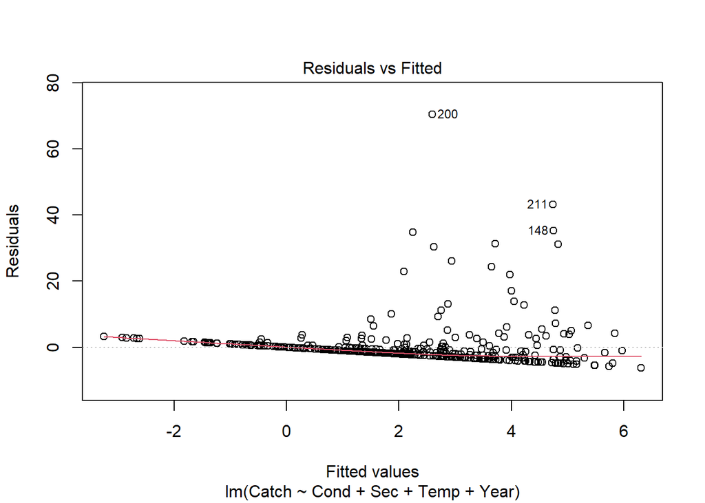

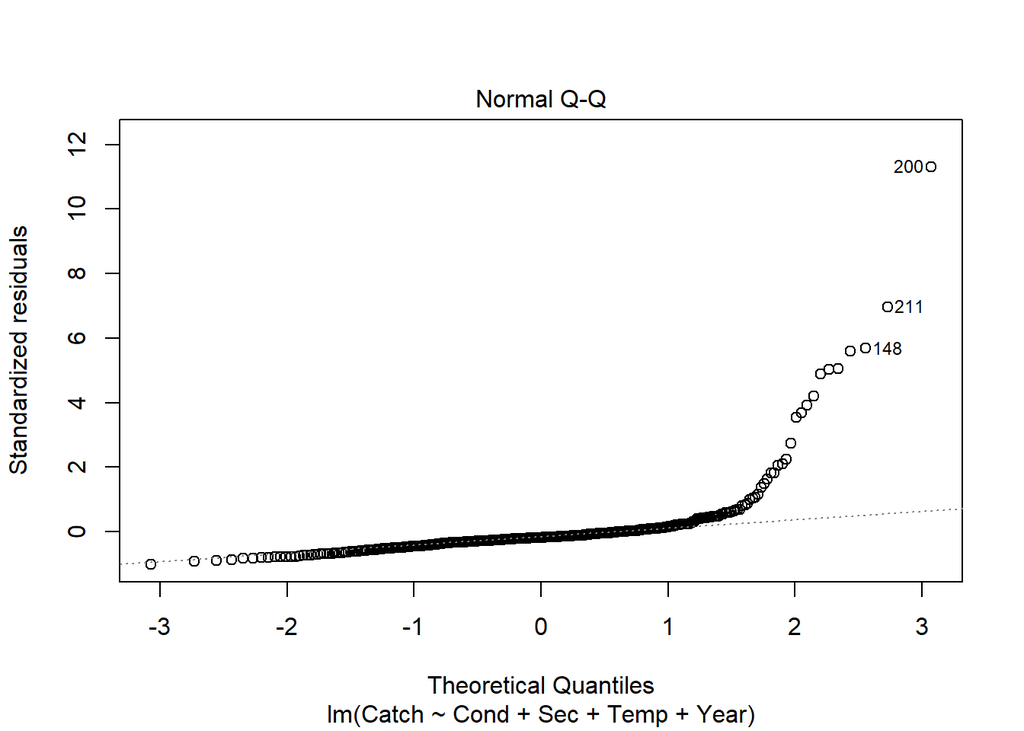

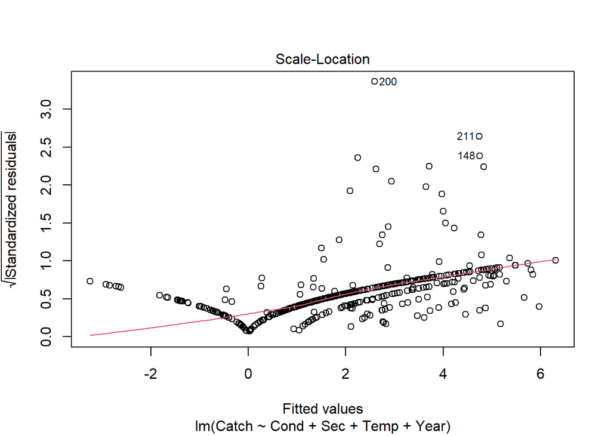

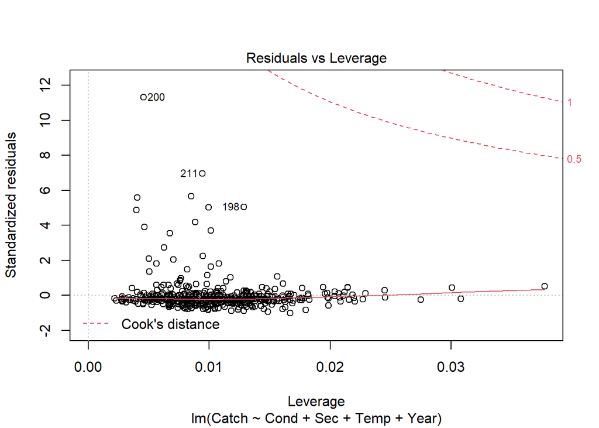

```r
plot(dslm)
```

You can see that the residuals versus fitted values are definitely not homogeneous, the QQ plot is no where near straight, and the scale-location plot is just weird.

### Poisson

As we discussed before, we don’t really want to log-transform this data anyway. Just by looking at the histogram of the log-transformed catch, we know it’s probably not appropriate to run a Poisson model, but I"m going to demo it anyway.

However, before we run it it helps to put all the explanatory variables on the same scale. We use the “scale” function to divide each value by the standard deviation and put the mean at zero. This makes the model happier. I’m not 100% sure why. It also makes it easier to interpret the relative strength of multiple predictor variables.

```r
FMWT_DS2 = mutate(FMWT_DS2, Cond = scale(ConductivityTop), Sec = scale(Secchi), Year2 = scale(Year),
         Temp = scale(WaterTemperature))


dsglm = glm(Catch~ Cond+Sec + Temp + Year2, family = poisson, data = FMWT_DS2)
summary(dsglm)
```

```
##
## Call:
## glm(formula = Catch ~ Cond + Sec + Temp + Year2, family = poisson,
##     data = FMWT_DS2)
##
## Deviance Residuals:
##     Min       1Q   Median       3Q      Max
## -5.2750  -1.6741  -1.1622  -0.6094  19.6121
##
## Coefficients:
##             Estimate Std. Error z value Pr(>|z|)
## (Intercept)  0.20104    0.04798   4.190 2.79e-05 ***
## Cond        -0.08735    0.04177  -2.091   0.0365 *
## Sec         -0.62283    0.04006 -15.546  < 2e-16 ***
## Temp        -0.27969    0.03567  -7.840 4.49e-15 ***
## Year2       -0.54682    0.05060 -10.807  < 2e-16 ***
## ---
## Signif. codes:  0 '***' 0.001 '**' 0.01 '*' 0.05 '.' 0.1 ' ' 1
##
## (Dispersion parameter for poisson family taken to be 1)
##
##     Null deviance: 3594.3  on 470  degrees of freedom
## Residual deviance: 2841.4  on 466  degrees of freedom
##   (6 observations deleted due to missingness)
## AIC: 3281.4
##
## Number of Fisher Scoring iterations: 7
```

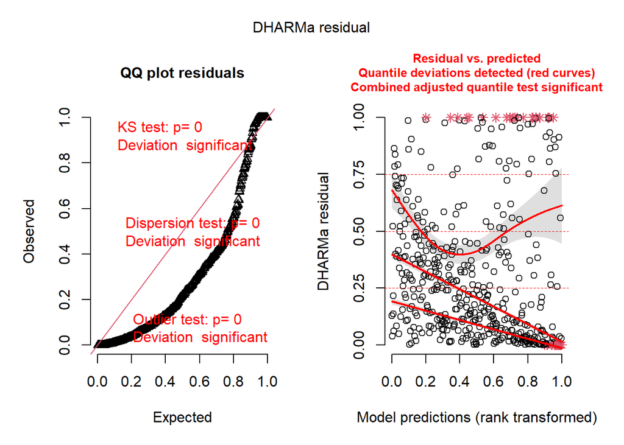

```r
#Wow! super significant. but how are we on those diagnostic plots?

simres = simulateResiduals(dsglm)
plot(simres)
```

OK, so we have major problems with our normal QQ plot and our residuals versus fitted plot.

Let’s test for dispersion

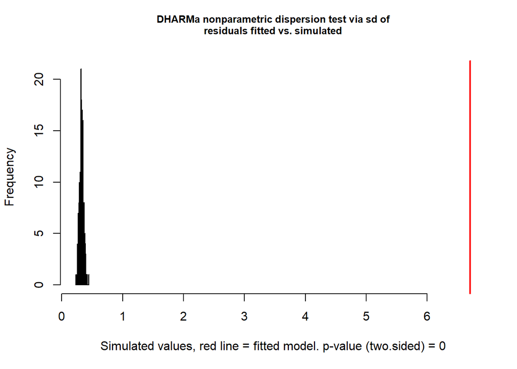

```
##
##  DHARMa nonparametric dispersion test via sd of residuals fitted vs.
##  simulated
##
## data:  simulationOutput
## dispersion = 20.51, p-value < 2.2e-16
## alternative hypothesis: two.sided
```

```r
testDispersion(simres)
```

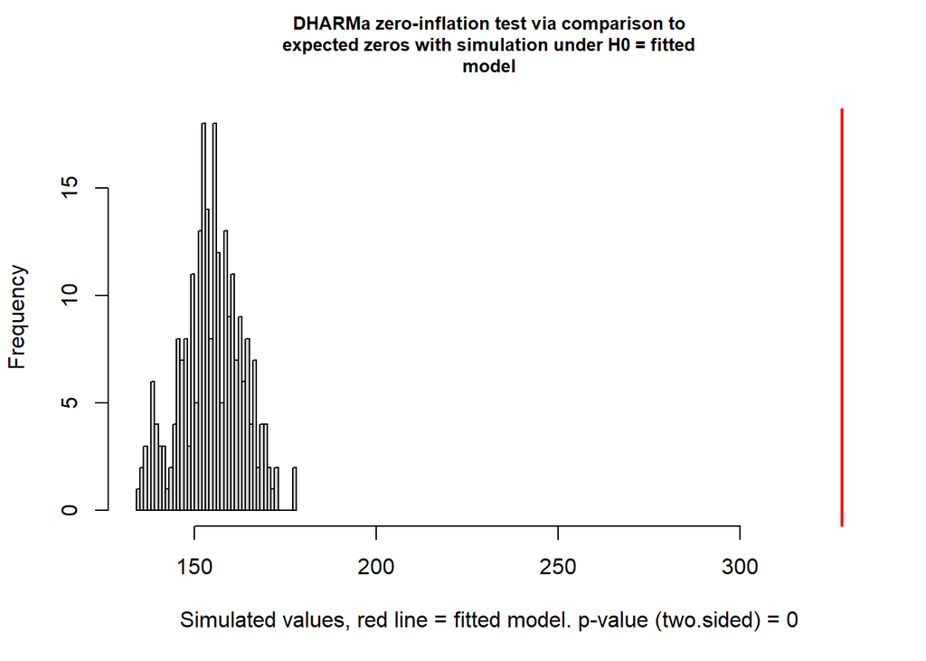

```
##
##  DHARMa zero-inflation test via comparison to expected zeros with
##  simulation under H0 = fitted model
##
## data:  simulationOutput
## ratioObsSim = 2.1114, p-value < 2.2e-16
## alternative hypothesis: two.sided
```

```r
testZeroInflation(simres)
```

Not good. We are way overdisperssed. Plus a few outliers. Poisson models are generally good at describing the mean, but they usually underestimate the variance.

### Negative Binomial

We can try and see if a negative binomial model fits better. Negative binomial distributions account for overdisperssion, and it worked pretty well on the striped bass data.

```r
dsnb2 = glmmTMB(Catch~  Cond + Sec + Year2+ (1|StationCode),  family = "nbinom1", data = FMWT_DS2)
summary(dsnb2)
```

```
##  Family: nbinom1  ( log )
## Formula:          Catch ~ Cond + Sec + Year2 + (1 | StationCode)
## Data: FMWT_DS2
##
##      AIC      BIC   logLik deviance df.resid
##   1230.5   1255.4   -609.2   1218.5      465
##
## Random effects:
##
## Conditional model:
##  Groups      Name        Variance Std.Dev.
##  StationCode (Intercept) 0.1153   0.3396
## Number of obs: 471, groups:  StationCode, 3
##
## Dispersion parameter for nbinom1 family (): 13.1
##
## Conditional model:
##             Estimate Std. Error z value Pr(>|z|)
## (Intercept)   0.3399     0.2421   1.404   0.1604
## Cond         -0.2679     0.1113  -2.406   0.0161 *
## Sec          -0.2018     0.0994  -2.030   0.0423 *
## Year2        -0.5974     0.1102  -5.421 5.93e-08 ***
## ---
## Signif. codes:  0 '***' 0.001 '**' 0.01 '*' 0.05 '.' 0.1 ' ' 1
```

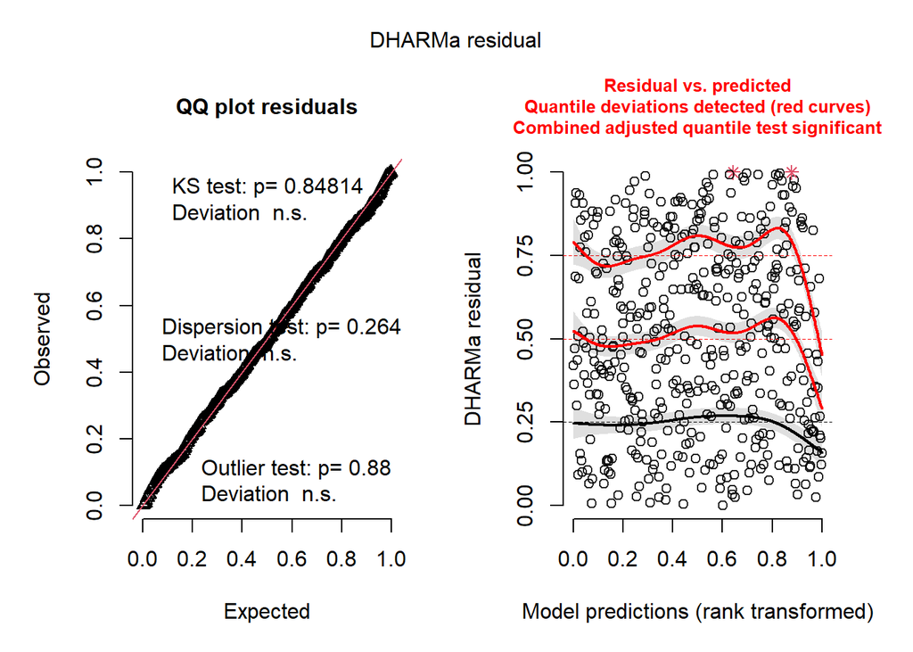

```r
simres = simulateResiduals(dsnb2)
plot(simres)
```

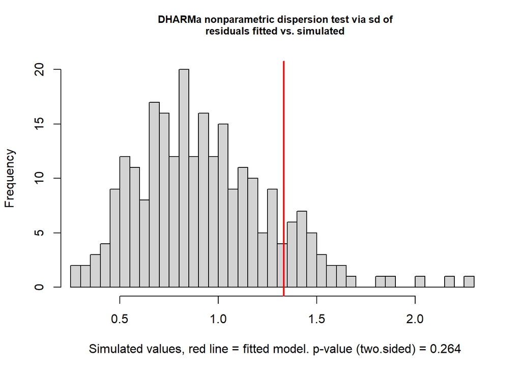

```
##
##  DHARMa nonparametric dispersion test via sd of residuals fitted vs.
##  simulated
##
## data:  simulationOutput
## dispersion = 1.4366, p-value = 0.264
## alternative hypothesis: two.sided
```

```r
testDispersion(simres)
```

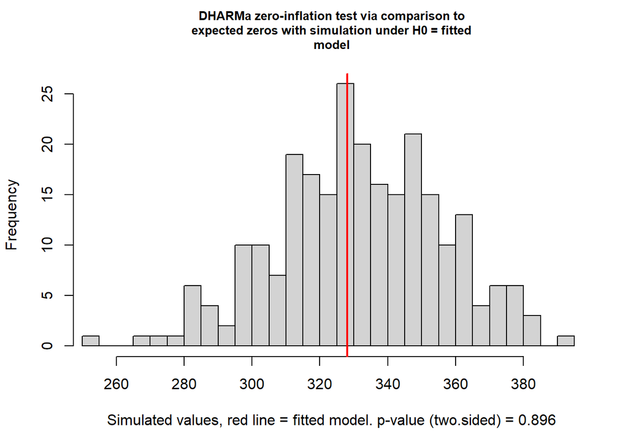

```
##
##  DHARMa zero-inflation test via comparison to expected zeros with
##  simulation under H0 = fitted model
##
## data:  simulationOutput
## ratioObsSim = 0.98756, p-value = 0.896
## alternative hypothesis: two.sided
```

```r
testZeroInflation(simres)
```

OK, so this doesn’t look as bad, but the residuals versus predicted plot shows “quantile deviations”. It doesn’t seem to be zero-inflated based on the test, but we do have a lot of zeros that could be causing those quantile deviations.

What do we do about those extra zeros?

## Too many Zeros

To deal with excess zeros, we can use a zero-inflated model, or a zero-augmented model (hurdle model) to figure out which to use, we need to understand the potential sources of zeros (modified from Zuur et al 2009):

1. Structural zeros. Delta smelt are not caught because the habitat is not suitable (too hot, to clear, too salty).
2. Design error. Delta smelt are not caught because the midwater trawl doesn’t sample the top part of hte water well and smelt hang out near the surface.
3. Observer error. Delta smelt were caught, but Rosie thought they were Wakasagi.
4. Smelt error. The habitat was suitable but the smelt weren’t using it.

Structural zeros and “smelt error” are considered “true zeros”, whereas design error and observer error are “false zeros”

Zero-augmented models (two-part models or hurdle models) do not differentiate between types of zeros. Zero-inflated models (mixture models) do differentiate so you can model zeros caused by the habitat being bad separately from the zeros caused by observer or design error.

Frequently, we can deal with data sets that have a lot of zeros just by using negative binomial models, or a few other tricks with our error terms. So, don’t jump right to the zero-inflated model UNLESS you have a clear conceptual model for why there might be different factors driving the ‘extra zeros’ than the counts.

In the case of the Delta Smelt, we know salinity, temperture, and turbidity are some of the major drivers of smelt presence and abundance. However, we know that smelt abundance has TANKED in recent years, and it isn’t really linked to changes in salinity, temperature, or turbidity at the local scale. Smelt often school, so when they are present, there are often several of them.

Therefore, we might want to try modeling the zeros seperate from abundance.

### ZIP and ZINB

The overdisperssion in our Poisson model may have just been caused by the extra zeros, so a zero inflated Poisson might work (but like I said before, Poisson models almost never work so don’t waste your time). If there was also overdisspersion in the counts, then a zero inflated negative binomial will work better. Therefore, we will try both models and see which works better. To run these models we use the `glmmTMB` package

```r
#try a zero-inflated Poisson
dszip = glmmTMB(Catch~  Cond + Sec + Temp + (1|StationCode), ziformula = ~ Year2,  family = "poisson", data = FMWT_DS2)
summary(dszip)
```

```
##  Family: poisson  ( log )
## Formula:          Catch ~ Cond + Sec + Temp + (1 | StationCode)
## Zero inflation:         ~Year2
## Data: FMWT_DS2
##
##      AIC      BIC   logLik deviance df.resid
##   2183.3   2212.4  -1084.6   2169.3      464
##
## Random effects:
##
## Conditional model:
##  Groups      Name        Variance Std.Dev.
##  StationCode (Intercept) 0.04929  0.222
## Number of obs: 471, groups:  StationCode, 3
##
## Conditional model:
##             Estimate Std. Error z value Pr(>|z|)
## (Intercept)  1.57676    0.13728  11.486  < 2e-16 ***
## Cond        -0.24852    0.04923  -5.048 4.47e-07 ***
## Sec         -0.37343    0.05163  -7.232 4.75e-13 ***
## Temp         0.22033    0.04331   5.087 3.64e-07 ***
## ---
## Signif. codes:  0 '***' 0.001 '**' 0.01 '*' 0.05 '.' 0.1 ' ' 1
##
## Zero-inflation model:
##             Estimate Std. Error z value Pr(>|z|)
## (Intercept)   0.9413     0.1188   7.923 2.31e-15 ***
## Year2         0.9540     0.1341   7.115 1.12e-12 ***
## ---
## Signif. codes:  0 '***' 0.001 '**' 0.01 '*' 0.05 '.' 0.1 ' ' 1
```

Note that the `ziformula` statement allows you to specify a different set of variables for the zero inflation part of it than the count part of it. So if you think that the counts are based on turbidity and salinity, but zeros are based on year. Using `~.` means you use the same set of variables for both models. You can also include random effects, and we have added a station-level random effect to take into account the fact that samples from the same station are not independent. IF you’re not familiar with random effects, those will be covered this afternoon.

So, this ran nicely, but as I mentioned before, Poisson distributions are almost never appropriate for data in the real world, so we should check our diagnostic plots.

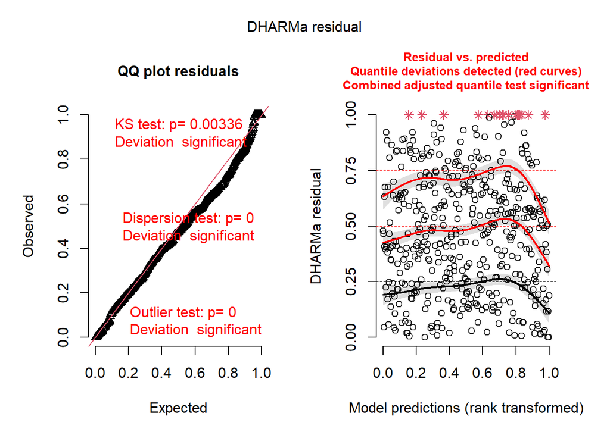

```r
simres = simulateResiduals(dszip)
plot(simres)
```

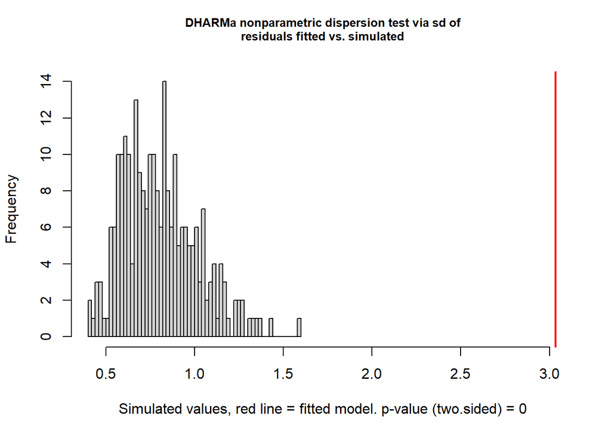

```
##
##  DHARMa nonparametric dispersion test via sd of residuals fitted vs.
##  simulated
##
## data:  simulationOutput
## dispersion = 3.7634, p-value < 2.2e-16
## alternative hypothesis: two.sided
```

```r
testDispersion(simres)
```

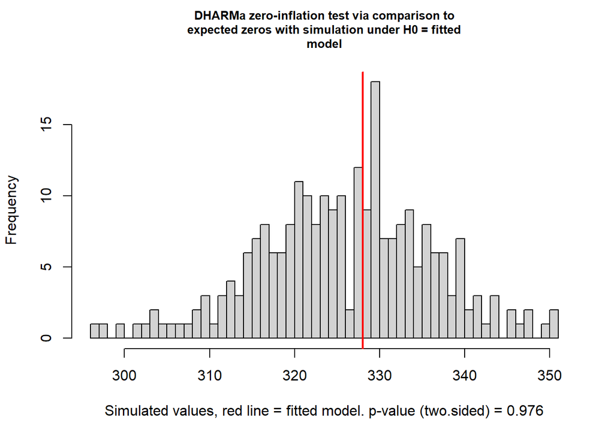

```
##
##  DHARMa zero-inflation test via comparison to expected zeros with
##  simulation under H0 = fitted model
##
## data:  simulationOutput
## ratioObsSim = 1.0051, p-value = 0.976
## alternative hypothesis: two.sided
```

```r
testZeroInflation(simres)
```

So we still had a lot of deviation. And outliers.

Now a zero-inflated negative binomial.

```r
dsnb4 = glmmTMB(Catch~  Sec +Cond+ Temp + (1|StationCode),
                zi =~  Year2,
                family = "nbinom1", data = FMWT_DS2, control=glmmTMBControl(optimizer=optim, optArgs=list(method="BFGS")))
summary(dsnb4)
```

```
##  Family: nbinom1  ( log )
## Formula:          Catch ~ Sec + Cond + Temp + (1 | StationCode)
## Zero inflation:         ~Year2
## Data: FMWT_DS2
##
##      AIC      BIC   logLik deviance df.resid
##   1182.8   1216.1   -583.4   1166.8      463
##
## Random effects:
##
## Conditional model:
##  Groups      Name        Variance Std.Dev.
##  StationCode (Intercept) 0.1135   0.3369
## Number of obs: 471, groups:  StationCode, 3
##
## Dispersion parameter for nbinom1 family (): 11.5
##
## Conditional model:
##             Estimate Std. Error z value Pr(>|z|)
## (Intercept)  0.66435    0.24563   2.705  0.00684 **
## Sec         -0.21691    0.09783  -2.217  0.02661 *
## Cond        -0.19197    0.11165  -1.719  0.08555 .
## Temp        -0.42736    0.08946  -4.777 1.78e-06 ***
## ---
## Signif. codes:  0 '***' 0.001 '**' 0.01 '*' 0.05 '.' 0.1 ' ' 1
##
## Zero-inflation model:
##             Estimate Std. Error z value Pr(>|z|)
## (Intercept)   -2.744      1.198  -2.290 0.022027 *
## Year2          3.787      1.065   3.556 0.000377 ***
## ---
## Signif. codes:  0 '***' 0.001 '**' 0.01 '*' 0.05 '.' 0.1 ' ' 1
```

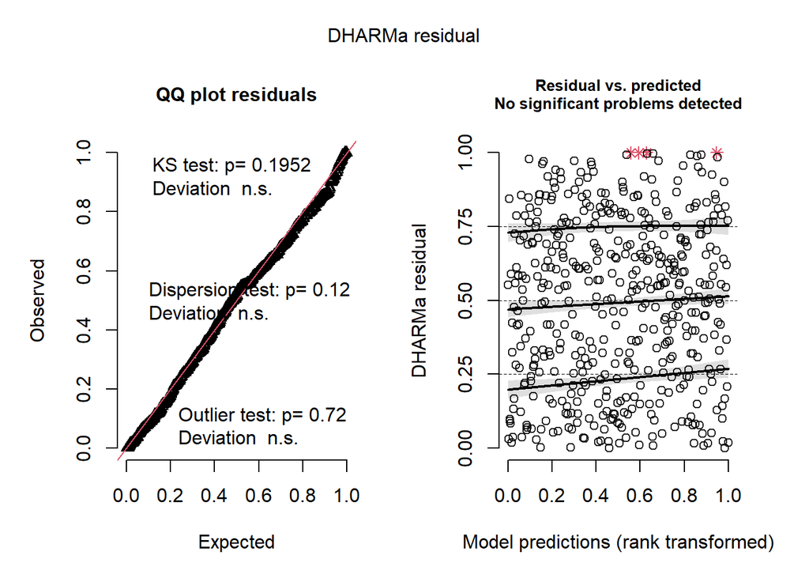

```r
dsres = simulateResiduals(dsnb4, plot = T)
```

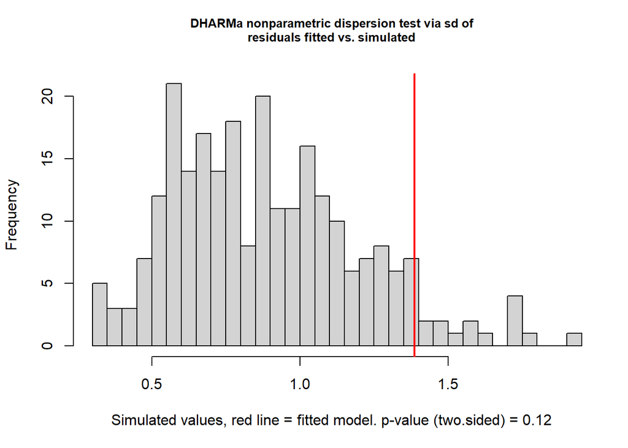

```
##
##  DHARMa nonparametric dispersion test via sd of residuals fitted vs.
##  simulated
##
## data:  simulationOutput
## dispersion = 1.5649, p-value = 0.12
## alternative hypothesis: two.sided
```

```r
testDispersion(dsres)
```

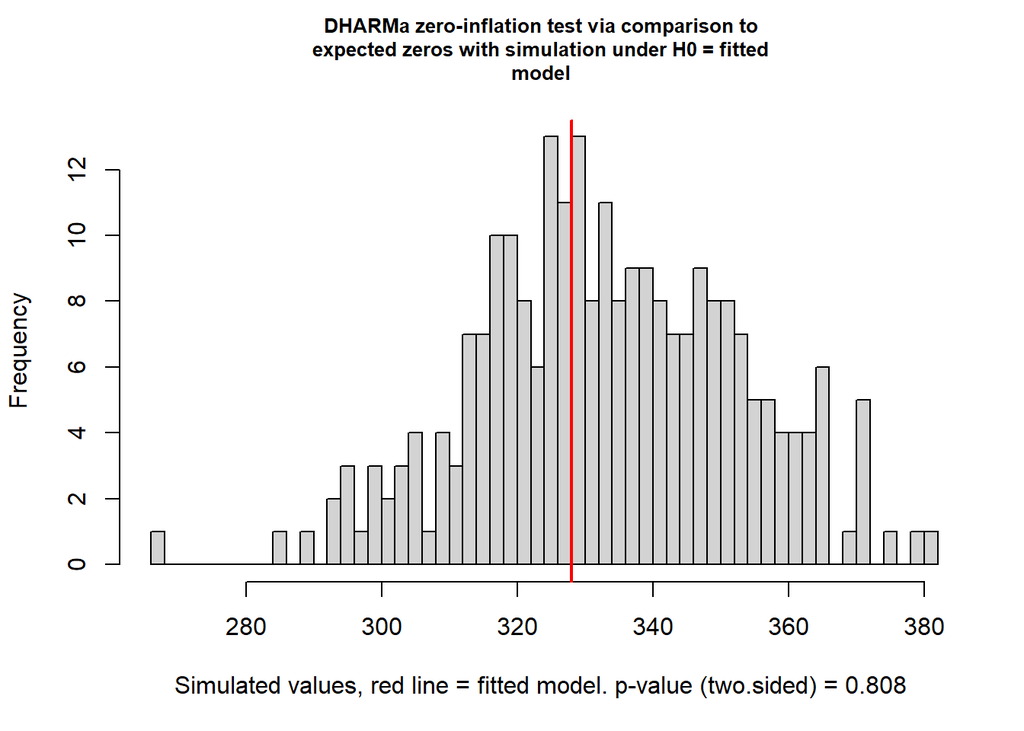

```
##
##  DHARMa zero-inflation test via comparison to expected zeros with
##  simulation under H0 = fitted model
##
## data:  simulationOutput
## ratioObsSim = 0.98266, p-value = 0.808
## alternative hypothesis: two.sided
```

```r
testZeroInflation(dsres)
```

So, we now have a lower AICc and a better residuals versus predicted values plot. That’s a pretty good model!

Let’s look at the coefficients again. The coefficients in the count model are what you are used to, but sometimes the results will look a little funny because they will not include the “extra” zeros. So the coefficients might look different from what you would expect based on the mean for each group. The zero-inflation model is a little harder to interpret. This is showing you the probability of “extra” zeros. Higher coefficients means more zeros, lower coefficients mean fewer zeros.

```r
summary(dsnb4)
```

```
##  Family: nbinom1  ( log )
## Formula:          Catch ~ Sec + Cond + Temp + (1 | StationCode)
## Zero inflation:         ~Year2
## Data: FMWT_DS2
##
##      AIC      BIC   logLik deviance df.resid
##   1182.8   1216.1   -583.4   1166.8      463
##
## Random effects:
##
## Conditional model:
##  Groups      Name        Variance Std.Dev.
##  StationCode (Intercept) 0.1135   0.3369
## Number of obs: 471, groups:  StationCode, 3
##
## Dispersion parameter for nbinom1 family (): 11.5
##
## Conditional model:
##             Estimate Std. Error z value Pr(>|z|)
## (Intercept)  0.66435    0.24563   2.705  0.00684 **
## Sec         -0.21691    0.09783  -2.217  0.02661 *
## Cond        -0.19197    0.11165  -1.719  0.08555 .
## Temp        -0.42736    0.08946  -4.777 1.78e-06 ***
## ---
## Signif. codes:  0 '***' 0.001 '**' 0.01 '*' 0.05 '.' 0.1 ' ' 1
##
## Zero-inflation model:
##             Estimate Std. Error z value Pr(>|z|)
## (Intercept)   -2.744      1.198  -2.290 0.022027 *
## Year2          3.787      1.065   3.556 0.000377 ***
## ---
## Signif. codes:  0 '***' 0.001 '**' 0.01 '*' 0.05 '.' 0.1 ' ' 1
```

Plot the coefficients.

```r
library(broom.mixed)
library(dotwhisker)

#organize the model output
t1 <-broom.mixed::tidy(dsnb4, conf.int = TRUE)
print(t1)
```

```
## # A tibble: 7 x 10
##   effect   component group  term  estimate std.error statistic  p.value conf.low
##   <chr>    <chr>     <chr>  <chr>    <dbl>     <dbl>     <dbl>    <dbl>    <dbl>
## 1 fixed    cond      <NA>   (Int~    0.664    0.246       2.70  6.84e-3    0.183
## 2 fixed    cond      <NA>   Sec     -0.217    0.0978     -2.22  2.66e-2   -0.409
## 3 fixed    cond      <NA>   Cond    -0.192    0.112      -1.72  8.56e-2   -0.411
## 4 fixed    cond      <NA>   Temp    -0.427    0.0895     -4.78  1.78e-6   -0.603
## 5 fixed    zi        <NA>   (Int~   -2.74     1.20       -2.29  2.20e-2   -5.09
## 6 fixed    zi        <NA>   Year2    3.79     1.07        3.56  3.77e-4    1.70
## 7 ran_pars cond      Stati~ sd__~    0.337   NA          NA    NA          0.121
## # ... with 1 more variable: conf.high <dbl>
```

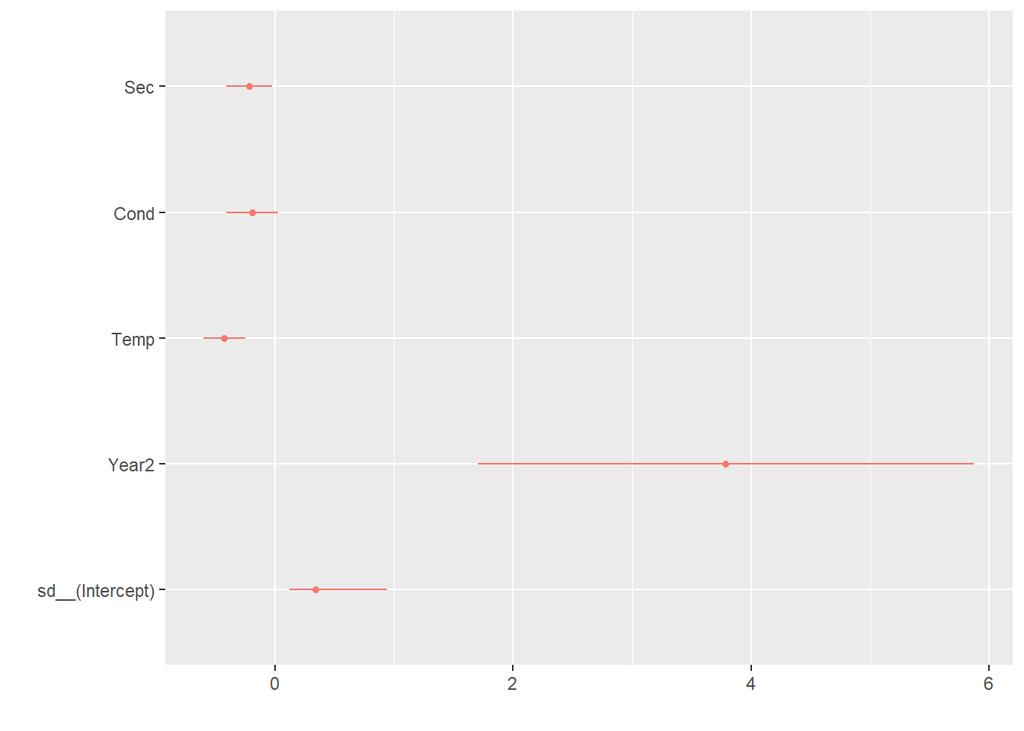

```r
#plot the coefficients
dwplot(t1)
```

We can also plot the cont model effects using the ‘effects’ package. Unfortunately it won’t do the zero-inflation term yet.

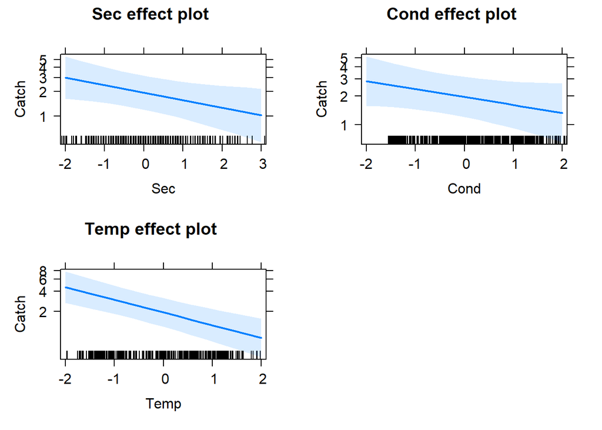

```r
plot(allEffects(dsnb4))
```

## Hurdle Model

Hurdle models can’t model the different types of models differently, so I haven’t used them as often. But they may be useful for certain situations, especially if you have high confidence in your presence/absence data, or very complicated model structure that doesn’t work with the glmmTMB function.

Hurdle models basically have two steps. They first run a binomial model on presence/absence. Then they subset the data to include only the “presences” and run a generalized linear model on those presences. You can do this ‘by hand’ by subsetting your data and running two models, or you can use the `glmmtmb` function from with a truncated negative binomial distribution.

```r
hurd = glmmTMB(Catch~ Cond +Sec + Temp + (1|StationCode), zi = ~ Year2,
               family = "truncated_nbinom1", data = FMWT_DS2)
summary(hurd)
```

```
##  Family: truncated_nbinom1  ( log )
## Formula:          Catch ~ Cond + Sec + Temp + (1 | StationCode)
## Zero inflation:         ~Year2
## Data: FMWT_DS2
##
##      AIC      BIC   logLik deviance df.resid
##   1242.7   1275.9   -613.3   1226.7      463
##
## Random effects:
##
## Conditional model:
##  Groups      Name        Variance  Std.Dev.
##  StationCode (Intercept) 2.559e-07 0.0005059
## Number of obs: 471, groups:  StationCode, 3
##
## Dispersion parameter for truncated_nbinom1 family ():   16
##
## Conditional model:
##             Estimate Std. Error z value Pr(>|z|)
## (Intercept)  -3.5079     4.6113  -0.761    0.447
## Cond         -0.8407     0.9091  -0.925    0.355
## Sec          -0.9088     0.6219  -1.461    0.144
## Temp         -2.2864     2.5958  -0.881    0.378
##
## Zero-inflation model:
##             Estimate Std. Error z value Pr(>|z|)
## (Intercept)   0.9930     0.1164   8.531  < 2e-16 ***
## Year2         0.9198     0.1290   7.129 1.01e-12 ***
## ---
## Signif. codes:  0 '***' 0.001 '**' 0.01 '*' 0.05 '.' 0.1 ' ' 1
```

You can see right away that the predictors that were significant using the zero-inflated negative binomial model are not significant using the hurdle model. So they are more useful when we model counts and zeros together than if we are just looking at counts.

Hurdle models are most useful when we think that ALL the zeros are caused by the same factors.

```r
hurd2 = glmmTMB(Catch~ Cond +Sec + Temp + (1|StationCode), zi = ~Cond +Sec + Temp + Year2,
               family = "truncated_nbinom1", data = FMWT_DS2)
summary(hurd2)
```

```
##  Family: truncated_nbinom1  ( log )
## Formula:          Catch ~ Cond + Sec + Temp + (1 | StationCode)
## Zero inflation:         ~Cond + Sec + Temp + Year2
## Data: FMWT_DS2
##
##      AIC      BIC   logLik deviance df.resid
##   1200.7   1246.4   -589.4   1178.7      460
##
## Random effects:
##
## Conditional model:
##  Groups      Name        Variance  Std.Dev.
##  StationCode (Intercept) 2.607e-07 0.0005106
## Number of obs: 471, groups:  StationCode, 3
##
## Dispersion parameter for truncated_nbinom1 family ():   16
##
## Conditional model:
##             Estimate Std. Error z value Pr(>|z|)
## (Intercept)  -3.5080     4.6113  -0.761    0.447
## Cond         -0.8407     0.9091  -0.925    0.355
## Sec          -0.9088     0.6219  -1.461    0.144
## Temp         -2.2864     2.5958  -0.881    0.378
##
## Zero-inflation model:
##             Estimate Std. Error z value Pr(>|z|)
## (Intercept)   1.1181     0.1284   8.709  < 2e-16 ***
## Cond         -0.0588     0.1284  -0.458  0.64694
## Sec           0.5005     0.1294   3.867  0.00011 ***
## Temp          0.6535     0.1203   5.433 5.54e-08 ***
## Year2         0.8326     0.1459   5.707 1.15e-08 ***
## ---
## Signif. codes:  0 '***' 0.001 '**' 0.01 '*' 0.05 '.' 0.1 ' ' 1
```

## Bonus example: Not all data with zeros needs a zero-inflated model

I spent a lot of time getting confused, because I had a data set I wanted to use for an example that had a TON of zeros, but the negative binomial model fit better than a zero-inflated negative binomial model. Then I found this blog post. I’ll copy some of it here.

https://statisticalhorizons.com/zero-inflated-models/

In cases of overdispersion, the ZIP model typically fits better than a standard Poisson model. But there’s another model that allows for overdispersion, and that’s the standard negative binomial regression model. In all data sets that I’ve examined, the negative binomial model fits much better than a ZIP model, as evaluated by AIC or BIC statistics. And it’s a much simpler model to estimate and interpret. So if the choice is between ZIP and negative binomial, I’d almost always choose the latter.

But what about the zero-inflated negative binomial (ZINB) model? It’s certainly possible that a ZINB model could fit better than a conventional negative binomial model regression model. But the latter is a special case of the former, so it’s easy to do a likelihood ratio test to compare them (by taking twice the positive difference in the log-likelihoods).* In my experience, the difference in fit is usually trivial.

Of course, there are certainly situations where a zero-inflated model makes sense from the point of view of theory or common sense. For example, if the dependent variable is number of children ever born to a sample of 50-year-old women, it is reasonable to suppose that some women are biologically sterile. For these women, no variation on the predictor variables (whatever they might be) could change the expected number of children.

So next time you’re thinking about fitting a zero-inflated regression model, first consider whether a conventional negative binomial model might be good enough. Having a lot of zeros doesn’t necessarily mean that you need a zero-inflated model.

### An example: striped bass data, revisited.

This time let’s use all the FMWT striped bass catch data instead of summaarizin gby survey.

```r
SB2 = filter(FMWT, Species %in% c("Striped Bass age-0", "Striped Bass age-1",
                                 "Striped Bass age-1", "Striped Bass age-2"),
             Year > 2000,  StationCode %in% c(600:700), !is.na(WaterTemperature), !is.na(Secchi)) %>%
              group_by(Year, SampleDate, SurveyNumber, WaterTemperature, Secchi, ConductivityTop, StationCode, Volume, Yr_type) %>%
              summarize(Catch = sum(Catch, na.rm = T))
```

```
## 'WaterTemperature', 'Secchi', 'ConductivityTop', 'StationCode', 'Volume'. You
## can override using the `.groups` argument.
```

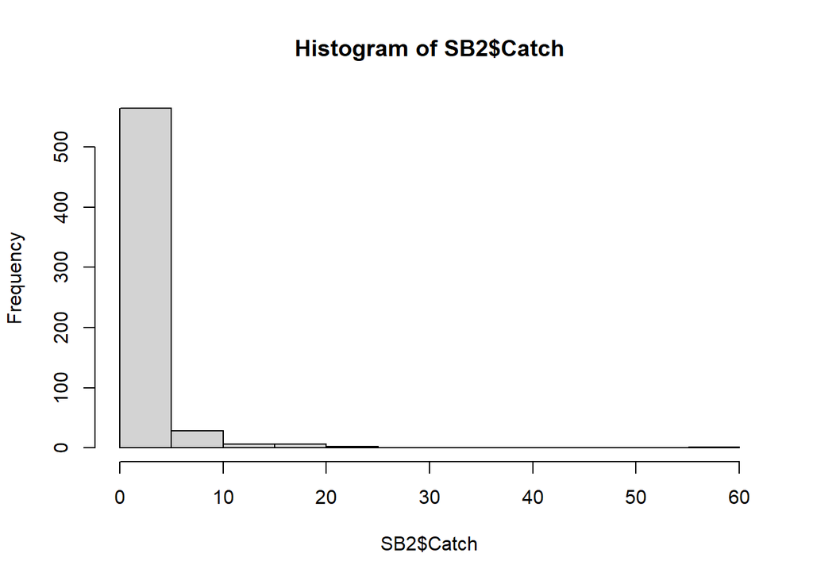

```r
hist(SB2$Catch)
```

So, as you see there are a lot of zeros.

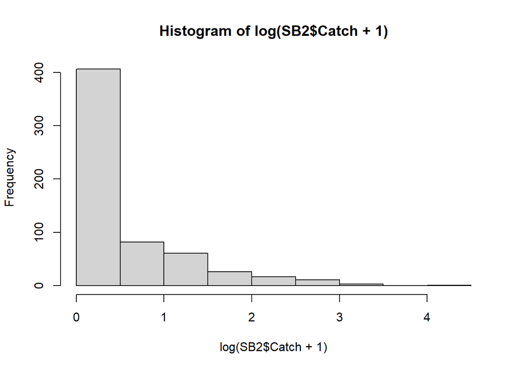

```r
hist(log(SB2$Catch+1))
```

Even log transformed, there are still a lot of zeros. But let’s see whether we need a zero-inflated model.

```r
anyNA(SB2$WaterTemperature)
```

```
## [1] FALSE
```

```r
SB2$Temp = scale(SB2$WaterTemperature)
SB2$Sec = scale(SB2$Secchi)
SB2$Year2 = scale(SB2$Year)
SB2$SampleID = 1:nrow(SB2)


SBnb = glmmTMB(Catch ~ Year2 + Temp + Sec + (1|StationCode), family = "nbinom1", data = SB2)
summary(SBnb)
```

```
##  Family: nbinom1  ( log )
## Formula:          Catch ~ Year2 + Temp + Sec + (1 | StationCode)
## Data: SB2
##
##      AIC      BIC   logLik deviance df.resid
##   1529.3   1555.7   -758.6   1517.3      601
##
## Random effects:
##
## Conditional model:
##  Groups      Name        Variance Std.Dev.
##  StationCode (Intercept) 0.06808  0.2609
## Number of obs: 607, groups:  StationCode, 7
##
## Dispersion parameter for nbinom1 family (): 5.36
##
## Conditional model:
##             Estimate Std. Error z value Pr(>|z|)
## (Intercept) -0.04650    0.14520  -0.320  0.74877
## Year2       -0.18436    0.06953  -2.652  0.00801 **
## Temp         0.31744    0.07333   4.329 1.50e-05 ***
## Sec         -0.62882    0.08895  -7.070 1.55e-12 ***
## ---
## Signif. codes:  0 '***' 0.001 '**' 0.01 '*' 0.05 '.' 0.1 ' ' 1
```

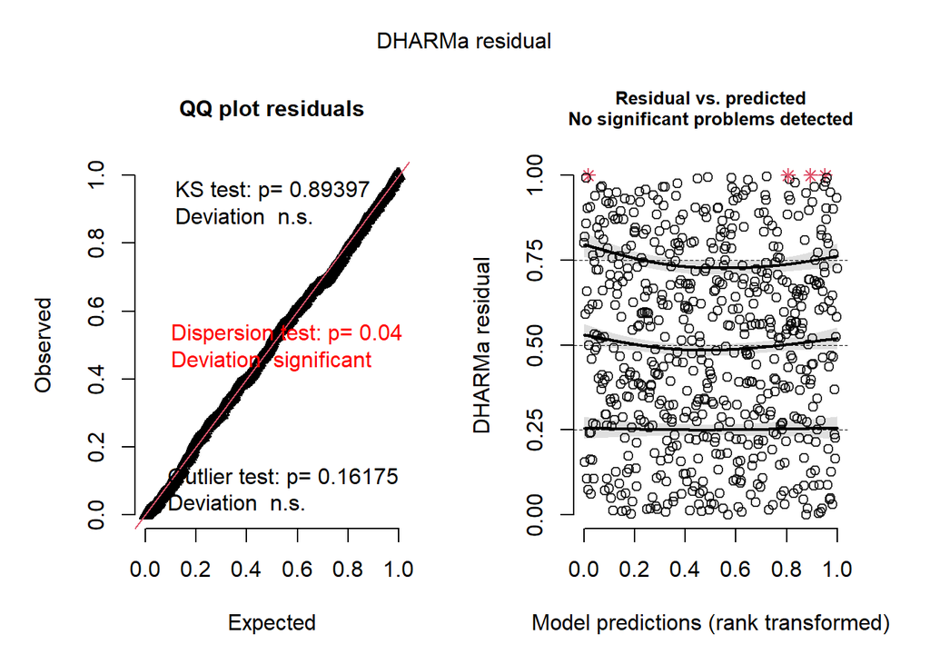

```r
simresSB = simulateResiduals(SBnb, plot = T)
```

```r
SBnb2 = glmmTMB(Catch ~ Year2+ Temp + Sec +  (1|StationCode), zi = ~Year2 +Sec+ Temp,  family = "nbinom1", data = SB2, control=glmmTMBControl(optimizer=optim, optArgs=list(method="BFGS")))
summary(SBnb2)
```

```
##  Family: nbinom1  ( log )
## Formula:          Catch ~ Year2 + Temp + Sec + (1 | StationCode)
## Zero inflation:         ~Year2 + Sec + Temp
## Data: SB2
##
##      AIC      BIC   logLik deviance df.resid
##   1528.4   1572.5   -754.2   1508.4      597
##
## Random effects:
##
## Conditional model:
##  Groups      Name        Variance Std.Dev.
##  StationCode (Intercept) 0.07318  0.2705
## Number of obs: 607, groups:  StationCode, 7
##
## Dispersion parameter for nbinom1 family (): 5.03
##
## Conditional model:
##             Estimate Std. Error z value Pr(>|z|)
## (Intercept) -0.06743    0.14802  -0.456   0.6487
## Year2       -0.15780    0.07255  -2.175   0.0296 *
## Temp         0.38478    0.07800   4.933 8.10e-07 ***
## Sec         -0.71868    0.09797  -7.336 2.21e-13 ***
## ---
## Signif. codes:  0 '***' 0.001 '**' 0.01 '*' 0.05 '.' 0.1 ' ' 1
##
## Zero-inflation model:
##              Estimate Std. Error z value Pr(>|z|)
## (Intercept) -13.93009    5.96184  -2.336   0.0195 *
## Year2         0.04347    0.76217   0.057   0.9545
## Sec          -4.72383    2.41256  -1.958   0.0502 .
## Temp          5.27921    2.49000   2.120   0.0340 *
## ---
## Signif. codes:  0 '***' 0.001 '**' 0.01 '*' 0.05 '.' 0.1 ' ' 1
```

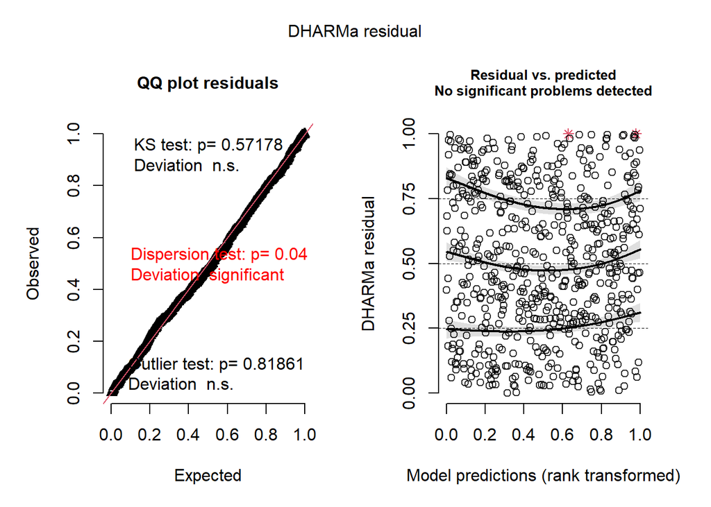

```r
simresSB2 = simulateResiduals(SBnb2, plot = T)
```

```r
AIC(SBnb)
```

```
## [1] 1529.253
```

```r
AIC(SBnb2)
```

```
## [1] 1528.447
```

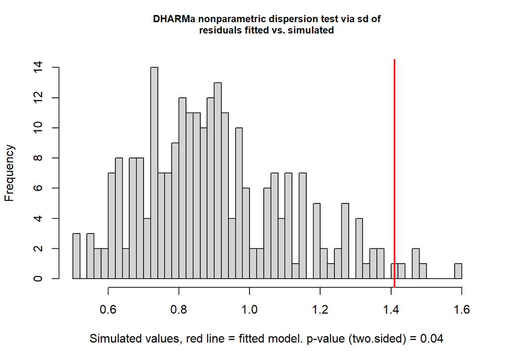

```
##
##  DHARMa nonparametric dispersion test via sd of residuals fitted vs.
##  simulated
##
## data:  simulationOutput
## dispersion = 1.5645, p-value = 0.04
## alternative hypothesis: two.sided
```

```r
testDispersion(simresSB)
```

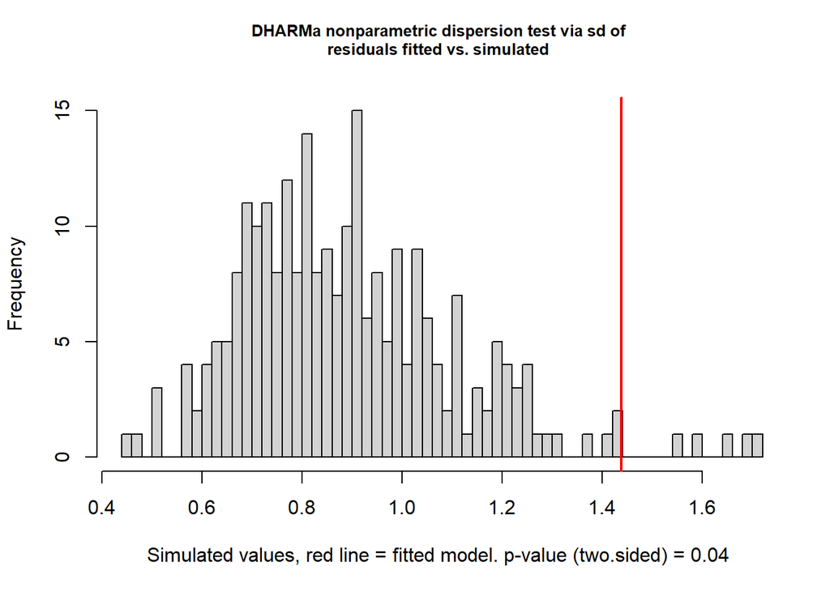

```
##
##  DHARMa nonparametric dispersion test via sd of residuals fitted vs.
##  simulated
##
## data:  simulationOutput
## dispersion = 1.6082, p-value = 0.04
## alternative hypothesis: two.sided
```

```r
testDispersion(simresSB2)
```

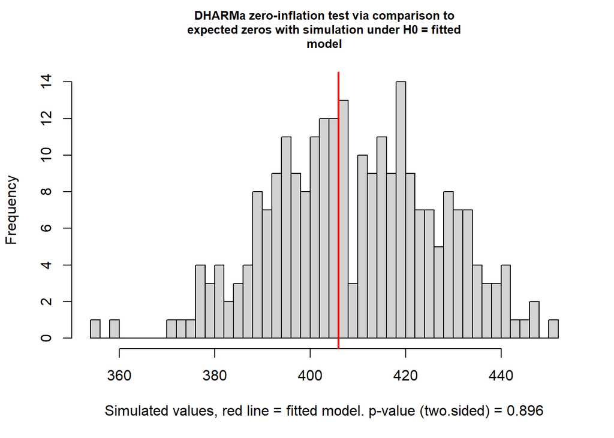

```
##
##  DHARMa zero-inflation test via comparison to expected zeros with
##  simulation under H0 = fitted model
##
## data:  simulationOutput
## ratioObsSim = 0.99083, p-value = 0.896
## alternative hypothesis: two.sided
```

```r
testZeroInflation(simresSB)
```

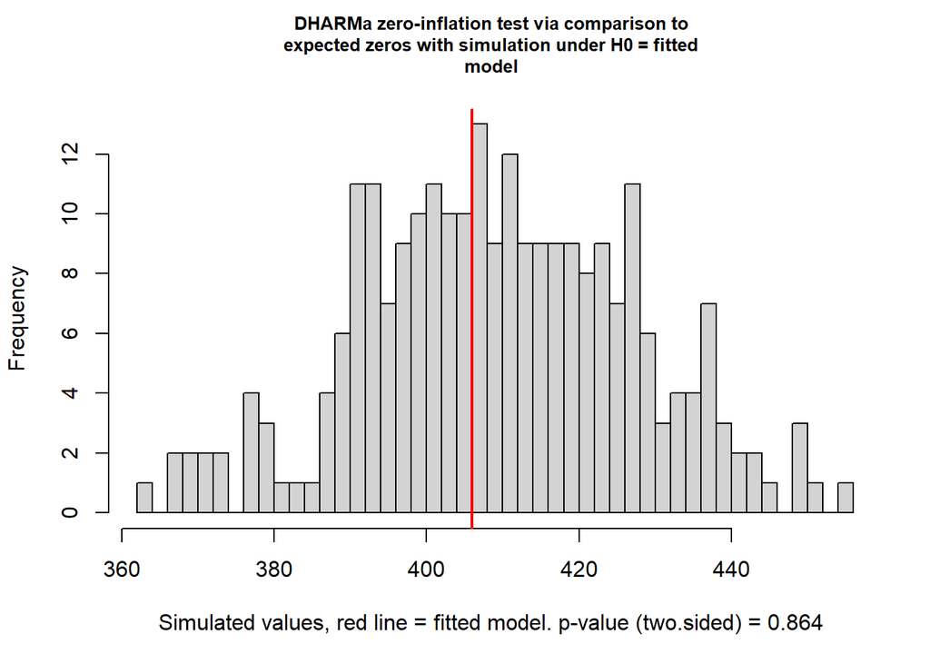

```
##
##  DHARMa zero-inflation test via comparison to expected zeros with
##  simulation under H0 = fitted model
##
## data:  simulationOutput
## ratioObsSim = 0.9906, p-value = 0.864
## alternative hypothesis: two.sided
```

```r
testZeroInflation(simresSB2)
```

So, both models are a little over dispersed, but both seem to handle the extra zeros just fine. The AICs are almost identical.

How do we deal with that overdispersion? We can ad a sample-level random effect. Don’t ask me why that works, but it does.

```r
SBnb3 = glmmTMB(Catch ~ Year2 + Temp + Sec + (1|StationCode)+ (1|SampleID), family = "nbinom1", data = SB2)
summary(SBnb3)
```

```
##  Family: nbinom1  ( log )
## Formula:
## Catch ~ Year2 + Temp + Sec + (1 | StationCode) + (1 | SampleID)
## Data: SB2
##
##      AIC      BIC   logLik deviance df.resid
##   1520.8   1551.6   -753.4   1506.8      600
##
## Random effects:
##
## Conditional model:
##  Groups      Name        Variance  Std.Dev.
##  StationCode (Intercept) 7.266e-10 2.696e-05
##  SampleID    (Intercept) 1.283e+00 1.133e+00
## Number of obs: 607, groups:  StationCode, 7; SampleID, 607
##
## Dispersion parameter for nbinom1 family (): 1.87
##
## Conditional model:
##             Estimate Std. Error z value Pr(>|z|)
## (Intercept)  -0.8047     0.2863  -2.811  0.00494 **
## Year2        -0.1774     0.0864  -2.053  0.04006 *
## Temp          0.4148     0.0932   4.450 8.57e-06 ***
## Sec          -0.7736     0.1139  -6.795 1.09e-11 ***
## ---
## Signif. codes:  0 '***' 0.001 '**' 0.01 '*' 0.05 '.' 0.1 ' ' 1
```

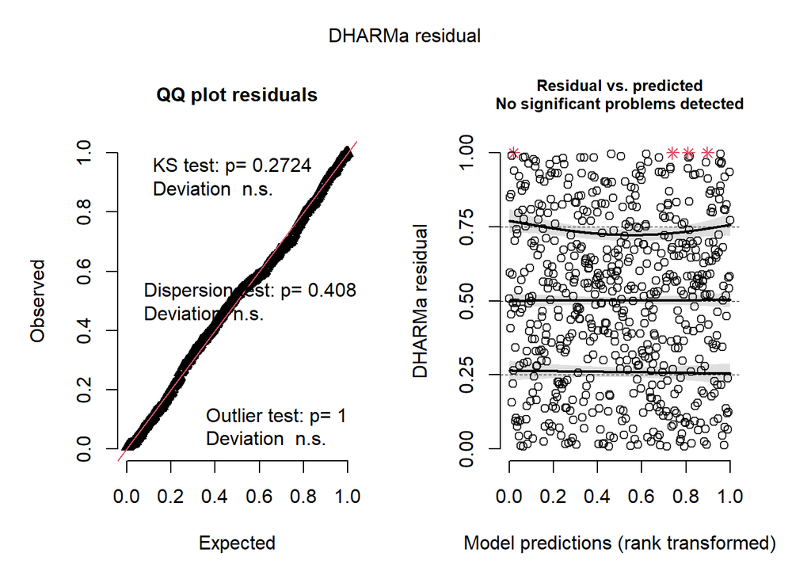

```r
simresSB3 = simulateResiduals(SBnb3, plot = T)
```

```r
SBnb4 = glmmTMB(Catch ~ Year2+ Temp + Sec +  (1|StationCode)+ (1|SampleID), zi = ~Year2 +Sec+ Temp,  family = "nbinom1", data = SB2, control=glmmTMBControl(optimizer=optim, optArgs=list(method="BFGS")))
summary(SBnb4)
```

```
##  Family: nbinom1  ( log )
## Formula:
## Catch ~ Year2 + Temp + Sec + (1 | StationCode) + (1 | SampleID)
## Zero inflation:         ~Year2 + Sec + Temp
## Data: SB2
##
##      AIC      BIC   logLik deviance df.resid
##   1522.3   1570.8   -750.1   1500.3      596
##
## Random effects:
##
## Conditional model:
##  Groups      Name        Variance  Std.Dev.
##  StationCode (Intercept) 2.562e-08 0.0001601
##  SampleID    (Intercept) 1.245e+00 1.1156045
## Number of obs: 607, groups:  StationCode, 7; SampleID, 607
##
## Dispersion parameter for nbinom1 family (): 1.87
##
## Conditional model:
##             Estimate Std. Error z value Pr(>|z|)
## (Intercept) -0.78870    0.25571  -3.084  0.00204 **
## Year2       -0.17069    0.08553  -1.996  0.04596 *
## Temp         0.43581    0.09237   4.718 2.38e-06 ***
## Sec         -0.78948    0.11282  -6.998 2.60e-12 ***
## ---
## Signif. codes:  0 '***' 0.001 '**' 0.01 '*' 0.05 '.' 0.1 ' ' 1
##
## Zero-inflation model:
##             Estimate Std. Error z value Pr(>|z|)
## (Intercept)  -321.94     443.84  -0.725    0.468
## Year2         -13.94      21.63  -0.645    0.519
## Sec           -87.36     121.52  -0.719    0.472
## Temp          132.31     182.38   0.726    0.468
```

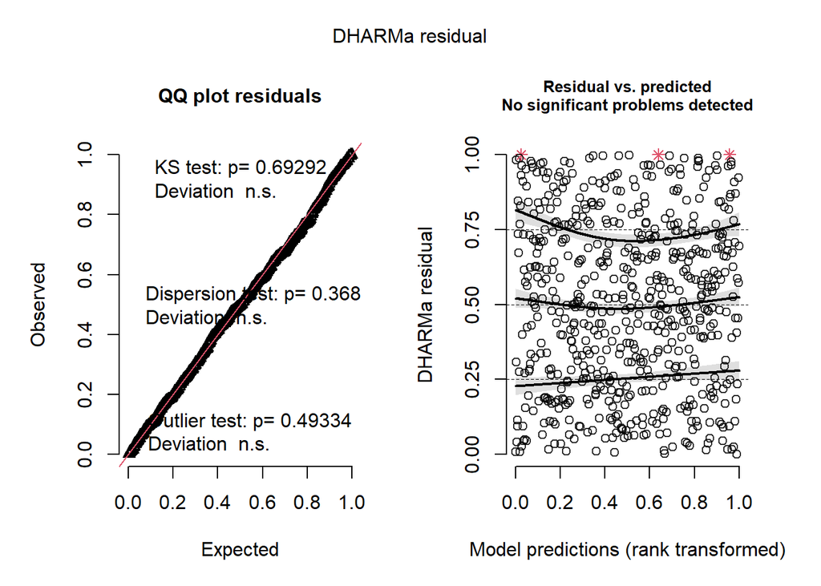

```r
simresSB4 = simulateResiduals(SBnb4, plot = T)
```

```r
AIC(SBnb3)
```

```
## [1] 1520.758
```

```r
AIC(SBnb4)
```

```
## [1] 1522.268
```

So, the AIC is almost the same, and both models fit the data well. We really don’t need the zero-inflation term, despite all the zeros! So keep it simple(r) and leave it out!